# The Swamp Generalist; *Agkistrodon piscivorus*

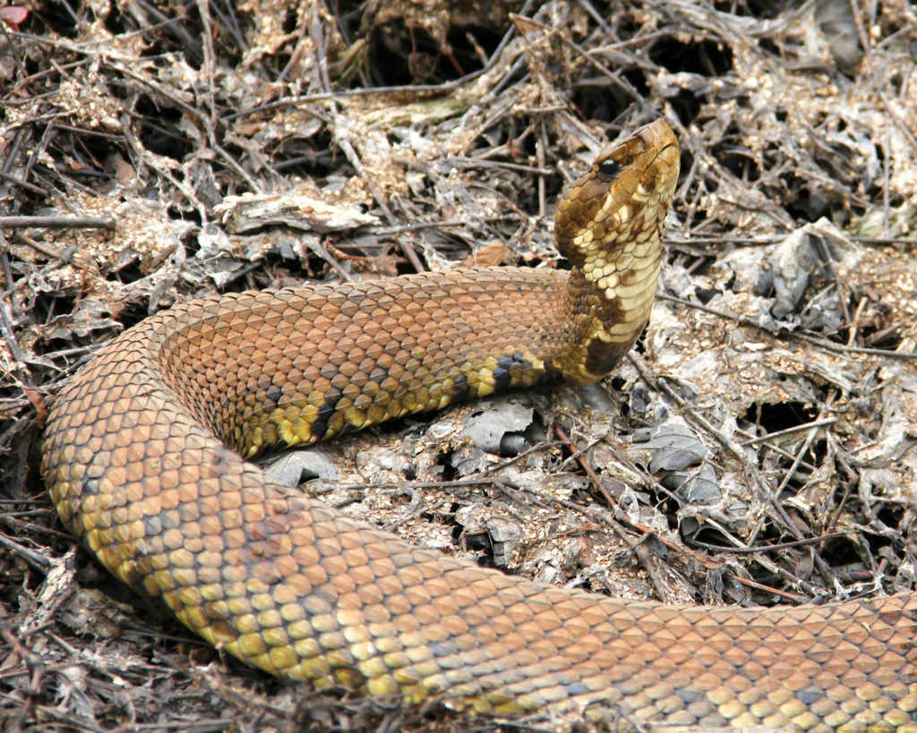

# 1 **Abstract**

# 2 **Introduction**

Wetlands are productive and biologically diverse systems that provide resources for a variety of wildlife species during part or all of their life stages (Mitsch and Gosselink 2000). Wetlands are often viewed as transitional ecosystems connecting terrestrial and aquatic systems, where fluctuations in hydrology can influence wetland boundaries to encroach or recede from the upland habitats (Brinson 1993). These wet-dry hydrologic fluctuations can cause habitat to become periodically unsuitable and resource-limited, as areas can become either too flooded or too dry (Brinson 1993). Fluctuations are typically both seasonal and stochastic and can cause some species to use wetland areas only during favorable conditions (i.e. specialists), or adopt more general use as the hydrological environmental changes (i.e. generalists) (Mitsch and Gosselink 2000, Devictor et al. 2008). As geomorphology shapes catchment area and water level retention in wetland systems, different wetland types have varying hydroperiods which range from more stable seasonal-depressional wetlands (Winter and Rosenberry 1998, Mitsch and Gosselink 2000) to highly variable riverine-floodplains (Junk et al. 1989). These differing wetland associations may conditionally favor certain strategies of habitat use, specifically, habitats with heterogenous environments and frequent disturbance regimes are typically colonized successfully by generalist species (Macarthur and Wilson 1967, Adler and Wilson 1987, Fournier et al. 2015, Büchi and Vuilleumier 2016).

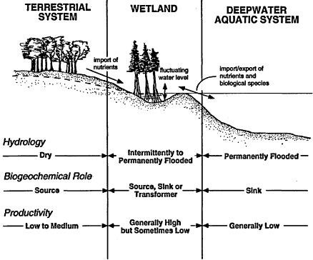

Mitsch & Gosselink, 2001

As environmental factors largely shape life history strategies at the broader scale, resource availability and competition may also play a role in determining habitat use at smaller scales (Mayor et al. 2009), where competitive exclusion forces organisms to alter their strategy of resource exploitation to become either highly specialized or adapt broad use of diets and habitats (Greenbaum 2004, Steen et al. 2014). As interspecific competition shapes evolutionary strategies of resource use between species (Levin 1970), so too does intraspecific competition (Amarasekare 2003). Intraspecific competition is thought to be more prevalent within species, so to avoid the limiting effects, inferior competitors tend to select resources not exploited by the superior (Bolnick 2004). A semi-aquatic species that is commonly found in a variety of wetland habitats throughout the southeastern United States is the cottonmouth (Agkistrodon piscivorus). Cottonmouths are dietary generalists, consuming anurans, fish, invertebrates, lizards, snakes, turtles, and smaller conspecifics (Gloyd and Conant 1990, McKnight et al. 2014). Cottonmouths are considered “habitat generalists” (Gloyd and Conant 1990, Enst and Ernst 2011), as they are found in many different aquatic-associated habitats, such as high elevation streams (Hill and Beaupre 2008), depressional wetlands (Eskew et al. 2009, Delisle et al. 2019b), and river floodplains (Ford et al. 2004, Roth 2005). Cottonmouths can also be abundant within appropriate habitats (Ford 2002), and often can have subtle differences in habitat selection across ontogeny (Eskew et al. 2009) and seasonal habitat selection differences between sexes (Delisle et al. 2019a, 2019b). Ontogenetic shifts in habitat selection and diet are thought to be a common competitive exclusion strategy in reptiles (Vitt 2000, Shine et al. 2003), and differences in habitat use between sexes in pit-vipers is relatively commonly (Reinert 1984, Pearson et al. 2002). However, populations inhabiting highly dynamic environments with high frequencies of disturbance may promote niche overlap and reduce habitat specialization among residents (Marvier et al. 2004, Mason et al. 2011, Durso et al. 2013, Smith et al. 2018, Stireman and Singer 2018). As cottonmouth populations occupy a variety of wetland habitats, populations inhabiting heterogeneous environments with frequent disturbance regimes should cause habitat selection to be driven predominantly by local environmental fluctuations rather than by population interactions

In this study, we sought to understand the habitat niche space of an isolated population of cottonmouths found within a riverine wetland slough along a transitional wetland gradient. We hypothesize that cottonmouths use generalist habitat selection as an adaptation to hydrologically dynamic ecosystems. To examine cottonmouth habitat niche space and habitat use, we (i) investigated cottonmouth use of the available habitat, (ii) determined whether there was a presence of intraspecific differences in habitat use among conspecifics, and (iii) determined which environmental factors promoted (were most predictive of) the occurrence of cottonmouths within our study area.

# 3 **Background**

The species *A. piscivorus* are located throughout the southeast United States, and are predominenty found near wetland habitats, such as marshes, riverine sloughs, and swamps (Parkinson et al. 2000, Porras et al. 2013).

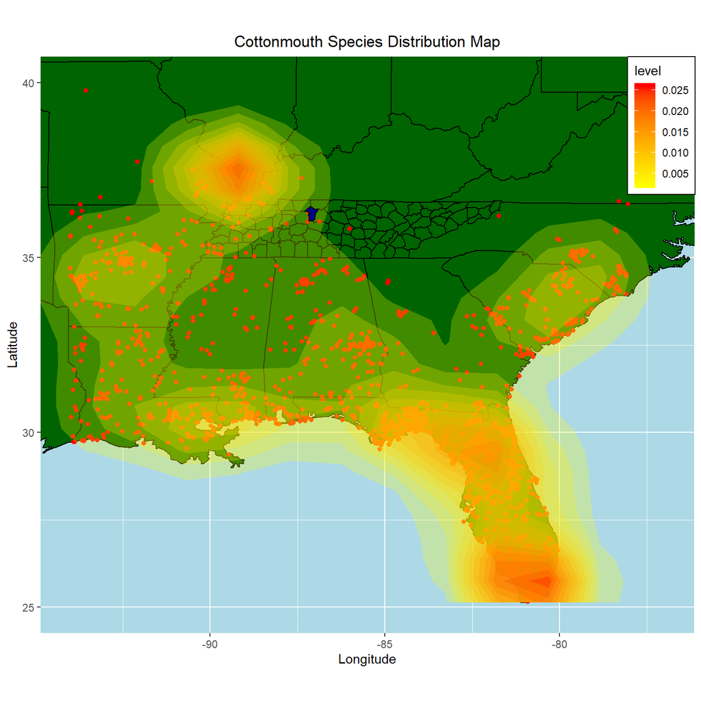

```r
extent <- extent(-94,-78,25,40)

# DISMO and GBIF

agk_dismo <- gbif("agkistrodon", species = "piscivorus", ext = extent, geo = TRUE, sp = TRUE, download = TRUE, removeZeros = TRUE)

#agk_dismo <- get_inat_obs(query = "Agkistrodon piscivorus")

agk_xy <- as.data.frame(cbind(agk_dismo@coords[,1],agk_dismo@coords[,2]))

#agk_xy<- as.data.frame(cbind(agk_dismo$longitude, agk_dismo$latitude))
colnames(agk_xy) <- c("longitude","latitude")

agk_xy<-cbind(agk_xy, data.frame("Species" = "Cottonmouth"))

us <- map_data("state")
#Outmap
state <- map_data("state")
county <- map_data("county")
study_site <- data.frame("x" = -87.092447, "y" = 36.288684)
tn <- county %>%
  filter(region=="tennessee")

Cheatham <- county %>%
  filter(region=="tennessee") %>%
  filter(subregion=="cheatham")


#Creating Distribution Map

ggplot(data = agk_xy, aes(x=longitude, y=latitude)) +
  geom_polygon(data = us, aes(x=long, y = lat, group = group), fill = "dark green", color="black") +
  geom_polygon(data = tn, aes(x=long, y = lat, group = group), fill = "dark green", color = "black") +
  geom_point(aes(x=longitude, y=latitude), color = "red") +
  stat_density2d(aes(fill = stat(level)), alpha= .25, geom = "polygon", data = agk_xy, n = 40)+
  scale_fill_gradient(low="yellow", high = "red")+
  geom_polygon(data = Cheatham, aes(x=long, y = lat, group = group), shape = 5,fill = "Dark Blue", color="black") +
  xlab("Longitude") +
  ylab("Latitude") +
  coord_fixed(xlim = c(-94,-77), ylim = c(25,40))+
  theme(panel.background = element_rect(fill = "lightblue"))+
  theme(legend.position=c(0.95, 0.88), legend.background = element_rect(fill="White",
      size=0.5, linetype="solid", colour ="black"))+
  ggtitle("Cottonmouth Species Distribution Map")+
  theme(plot.title = element_text(hjust = 0.5))
```

**Map 1:** The distribution of cottonmouth (*A. piscivorus*) throughouth the continental United States based on museum specimens from the GBIF database (https://www.gbif.org/). The study area was conducted in Cheatham County, TN, which is highlighted in dark blue.

# 4 **Methods**

```r
study<-read.csv("data/CottonmouthTotal-11-27.csv")
```

## 4.1 Study Area

Data was collected along the Cumberland River Bicentennial Trail (CRBT), Cheatham County, Tennessee, USA (36˚17’ N, 87˚05’W). The site is a mixture of lowland forest, slough wetlands, upland limestone bluffs, and rocky outcrops. Cottonmouths use the upland forest and limestone bluffs as overwintering sites and occupy the lowland forest slough during the active season. The site is bordered by limestone bluffs and backwater streams along the northern portions, the Cumberland River along the west and south, and crop fields and urban development along the southern portions. These landscape features appear to largely isolate the population from dispersal and unpublished telemetry data (Smith 2009, Fulbright 2014) noted that snakes did not leave the approximately 76 hectare study area.

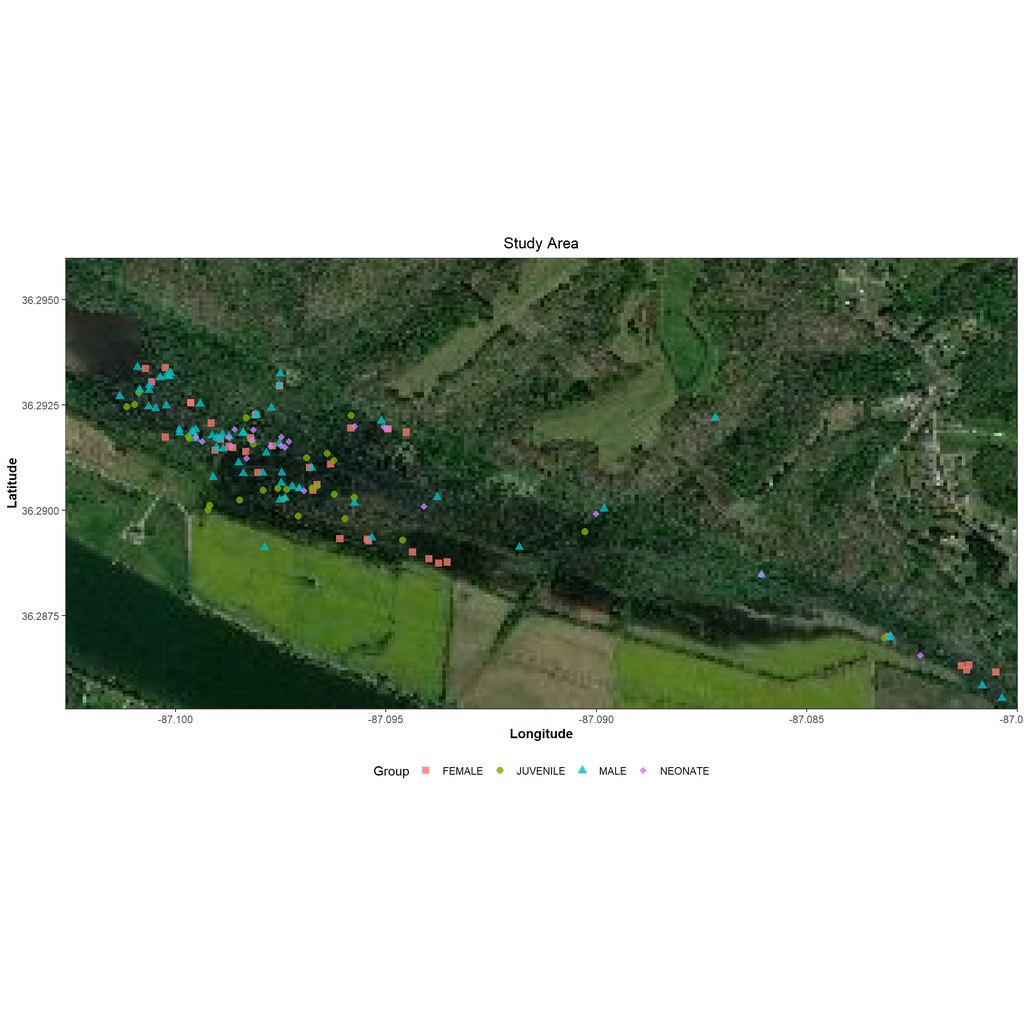

```r
#Setting Up Coordinates

coord<-cbind(study$UTM_mE, study$UTM_mN)
coord_locations<-SpatialPoints(coord,
                               proj4string = CRS("+proj=utm +zone=16 +datum=WGS84"))
lat.lon<- as.data.frame(spTransform(
  coord_locations, CRS("+proj=longlat +datum=WGS84")))
colnames(lat.lon)<-c("x","y")

study<-cbind(study,lat.lon)

#Subsets of Dataset

habitat<- study %>% subset(Type == "GENERAL")
snake<- study %>% subset(Type == "SNAKE")

#Raster from OSM

raster <- openmap(c(max(lat.lon$y)+0.01, min(lat.lon$x)-0.01),
                  c(min(lat.lon$y)-0.01, max(lat.lon$x)+0.01),
                  type = "bing")

raster_utm <- openproj(raster,
              projection = "+proj=longlat +datum=WGS84")

autoplot(raster_utm, expand = TRUE) + theme_bw() +
  theme(legend.position="bottom") +
  geom_point(data=snake, aes(x,y, shape=Group, color = Group), size = 2.5, alpha = 0.8) +
  scale_shape_manual(values = c(15,16,17,18))+
  coord_fixed(xlim = c(min(habitat$x),max(habitat$x)), ylim = c(min(habitat$y),max(habitat$y)))+
  theme(axis.title = element_text(face="bold")) + labs(x="Longitude",
        y="Latitude")+
  ggtitle("Study Area")+
  theme(plot.title = element_text(hjust = 0.5))
```

The habitat types found within the study area are the buttonbush slough in the central portion (12.6 ha), characterized by relatively open canopy, deeper water (50-150 cm), and mats of floating vegetation (Hydrocotyle ranunculoides & Ludwigia palustris) scattered throughout the slough. An open water habitat (> 100cm) is located toward the western portion of the study area. The seasonally flooded lowland forest (20.9 ha), dominated by red maples (Acer rubrum), has the denser canopy closure for the wetland, and is located between the slough and upland forest. Toward the southern portion between the slough and crop fields is a transitional edge area (15.4 ha) dominated by dense grass vegetation and occasionally floods (<10cm) in some portions throughout the year. The upland forest habitat (16.3 ha) was dominated by oak trees (Quercus sp.) and had dense canopy closure and higher percentage of bare soil. Three main streams flow into the slough from the upland forest and provide a permanent source of water to the slough, along with periodic flooding from the Cumberland River, and groundwater seepage. A constructed levee divides the slough from adjacent crop fields, and during the fall waterfowl hunt, a culvert is opened from the levee to reduce the flooded areas.

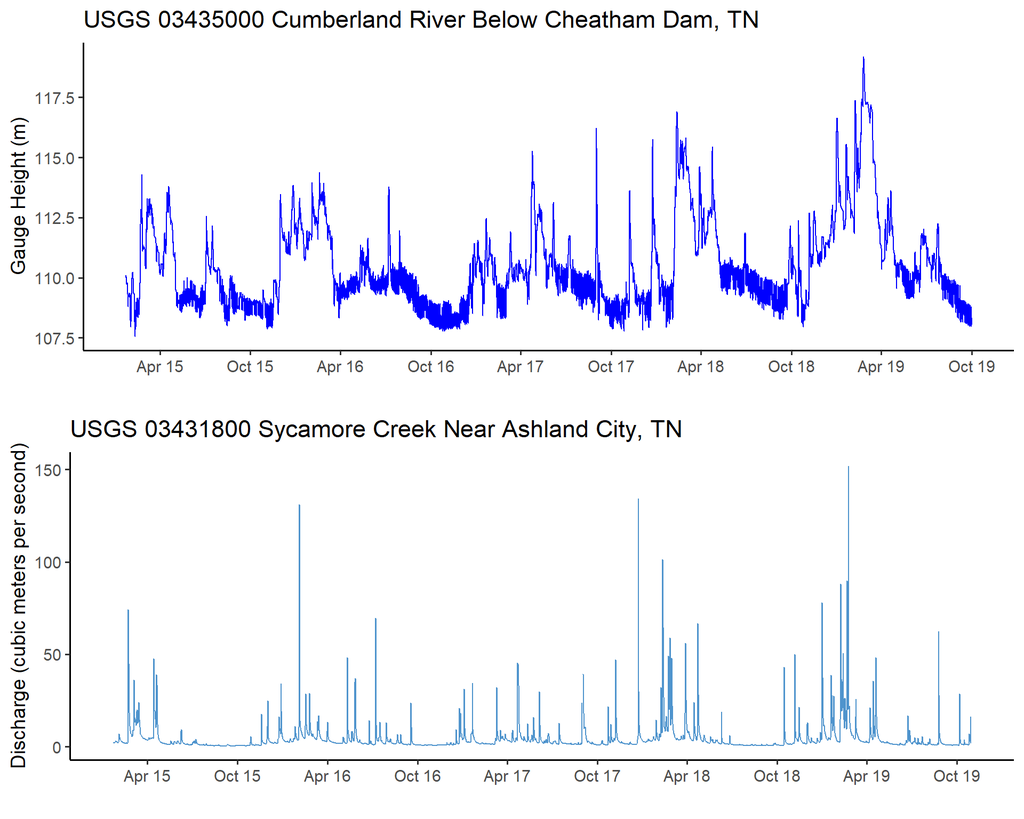

```r
gauge<-read.csv("data/GaugeData-USGS.csv")
gauge[,2]<-as.Date(gauge[,2])
gauge[,4]<-gauge[,3]*0.3048

p1<-ggplot(gauge, aes(x =gauge$datetime, y= gauge$V4))+
  geom_line(color = "blue")+
  xlab("")+
  ylab("Gauge Height (m)")+
  ggtitle("USGS 03435000 Cumberland River Below Cheatham Dam, TN")+
  theme_classic(base_size = 14)

p1<-p1+scale_x_date(breaks=date_breaks("6 months"), labels = date_format("%b %y"))

discharge<-read.csv("data/SycamoreData-USGS.csv")
discharge[,2]<-as.Date(discharge[,2])
discharge[,4]<-discharge[,3]*0.0283168

p2<-ggplot(discharge, aes(x =discharge$datetime, y= discharge$V4))+
  geom_line(color = "steelblue3")+
  xlab("")+
  ylab("Discharge (cubic meters per second)")+
  ggtitle("USGS 03431800 Sycamore Creek Near Ashland City, TN")+
  theme_classic(base_size = 14)

p2<-p2+scale_x_date(breaks=date_breaks("6 months"), labels = date_format("%b %y"))

plot_grid(p1,p2, ncol = 1, nrow = 2)
```

## 4.2 Field Collection

We conducted visual encounter surveys during the active seasons (April – October) and snakes were captured using tongs and retained in plastic restraining tubes (Midwest Tongs). For individual identification, each snake was implanted subcutaneously with a Passive Integrated Transponder (PIT) tag (Biomark) on the ventral side, posterior to midbody. Tags and implant syringes were soaked in Benzalkonium Chloride (Benz-all) for 2 – 3 minutes prior to tag implantation, and an antiseptic liquid bandage (Vetclose) was applied to the insertion area to facilitate healing. Snout-vent length (SVL) and tail lengths (TL) were measured, and snakes were sexed by either everting hemipenes or by probing (Blanchard and Finister 1933). Individuals were considered adults if their SVL were greater than 500-mm, individuals with an SVL between 300 – 500-mm were considered juveniles (Burkett 1966, Eskew et al. 2009), and neonates were considered to be individuals less than 300-mm SVL (Koons et al. 2009). Body mass was measured with a Pesola spring scale.

Habitat selection was quantified by recording a suite of biotic and abiotic environmental variables that shared the transitional wetland gradient relationship from terrestrial to aquatic habitat, (Table 1) at the location in which the individual was first sighted. A 1-m2 quadrat was used to assess the habitats available compared to those selected by cottonmouths; a combination of randomly chosen and fixed sites were measured. A randomly chosen comparison site was paired with each snake location using the Random Points Tool in ArcMap (ESRI) within the study area. Secondarily, a grid of 40 systematically selected fixed sites were placed ~200-m from one another using the Fishnet Tool in ArcMap, to assure all available habitats in the study area were quantified.

To test if cottonmouths are generalist or specialist in habitat selection, we used the National Land Cover Dataset (NLCD, 2011), by the USGS downloaded from Google Earth Engine (https://earthengine.google.com/), to identify the habitats cottonmouths were located within. Land cover types were generalized to three categories; Terrestrial, Aquatic, and Wetland.

```r
landcover<-raster("data/Habitat/Land_Classification.tif")

# Converting projection of raster

projection(landcover)<-CRS("+proj=longlat +ellps=WGS84")

#Extracting Values
lat.lon<-data.frame(cbind(study$x,study$y))

results<-data.frame(raster::extract(landcover$Land_Classification, SpatialPoints(lat.lon), sp = T))

study<-cbind(study,results$Land_Classification)

#Changing values
levels(study$`results$Land_Classification`)<-c(levels(study$`results$Land_Classification`), c("Aquatic", "Wetland","Terrestrial"))
study$`results$Land_Classification`[study$`results$Land_Classification`<=11] <- "Aquatic"
study$`results$Land_Classification`[study$`results$Land_Classification`>11 & study$`results$Land_Classification`< 89] <- "Terrestrial"
study$`results$Land_Classification`[study$`results$Land_Classification`>=90 & study$`results$Land_Classification`<= 95]<- "Wetland"
```

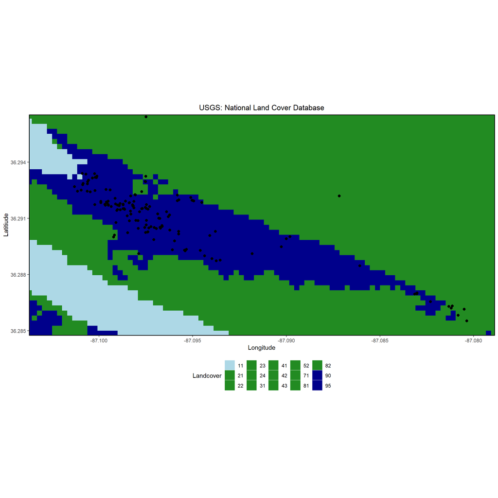

```r
rast<-rasterToPoints(landcover)
rast<-data.frame(rast)
colnames(rast)<-c("X","Y", "Landcover")
b.rast<-seq(min(rast$Landcover), max(rast$Landcover), length.out = 30)
rast$Landcover<-as.character(rast$Landcover)

ggplot()+
geom_raster(data = rast,aes(X, Y, fill = Landcover))+
  scale_fill_manual(values= c("light blue", "forestgreen","forestgreen","forestgreen","forestgreen","forestgreen","forestgreen",
                               "forestgreen","forestgreen","forestgreen","forestgreen","forestgreen","forestgreen","Dark blue", "Dark blue"))+
  geom_point(data = snake, aes(x,y), size = 2)+
  coord_fixed(xlim = c(min(habitat$x),max(habitat$x)), ylim = c(min(habitat$y),max(habitat$y)))+
  theme(panel.border = element_rect(colour = "black", fill = NA, size = 1))+
  labs(x = "Longitude", y = "Latitiude")+
  ggtitle("USGS: National Land Cover Database")+
  theme(plot.title = element_text(hjust = 0.5))+
  theme(legend.position= "bottom")
```

**Map 3:** The USGS: National Land Cover Dataset of 2011 downloaded from the Google Earth Engine. CLassification definitions can be found at (https://developers.google.com/earth-engine/datasets/catalog/USGS_NLCD). Cottonmouth locations are identified by the black points on the map. Green indicates terrestrial habitat, light blue indicates deep-water habitats, and dark blue indicates wetland habitats.

## 4.3 Analysis of Habitat Selection: Ecological Niche

The concept of the ecological niche was used as a framework to analyze the range of environmental variables cottonmouths selected within the general habitats available. A correlation matrix was used to identify colinear environmental variables, and variables with a coefficient above 0.70 were removed from analysis (Dormann et al. 2013). We found land cover and water cover to be highly correlated as well as three temperature variables; ambient, surface, and substrate temperature. Therefore, we chose to remove land cover and substrate temperature, while averaging both surface and ambient temperature to a single mean temperature variable, leaving 16 environment variables for analysis (Table 1). We used Principal Component Analysis (PCA) on correlations to reduce dimensionality of the environmental variables to better interpret the variation within each habitat dimension to elucidate trends of cottonmouth habitat niche width. Each dimension was ranked based on explained variance (Peres-Neto et al. 2003) and we retained the first three principal components for further analysis.PCA was performed using R (www.r-project.org) and plotted using ggplot2 package (WICKHAM 2016).

## 4.4 Analysis of Habitat Selection: Intra-specific Differences

To test for intra-specific differences in habitat selection, an ANOVA (Analysis of Variance) was used to compare conspecific group component scores (adult males, adult females, juveniles, and neonates) and was followed by Tukey’s HSD post-hoc tests. Linear regression was used to evaluate the presence of an ontogenetic shift in habitat use by comparing snake SVL with individual component scores (Eskew et al. 2009).

## 4.5 Analysis of Habitat Selection: Modeling Habitat Preference

Random Forest (RF) classification (Breiman 2001) was used to identify the important environmental variables that predict cottonmouth habitat selection. RF is a nonparametric classification method that builds an ensemble model based on a large set of decision trees. For each tree, a bootstrap sample of approximately 64% (i.e., bag sample) was used as a training set, and the remaining data left out as a validation set (i.e., out-of-bag [OOB]) (Breiman 2001, Severson et al. 2017). RF uses all constructed trees within a model to predict and estimate the overall OOB error rate, which is treated as a metric of model accuracy (Breiman 2001, Cutler et al. 2007, Severson et al. 2017).

We constructed an optimal model for classifying cottonmouth habitat selection from the measured environmental variables using cottonmouth occurrence sites compared to available habitat sites as pseudo-absences. We applied 30-iterations of RF models, using the randomForest package (Breiman et al. 2018), where each iteration used 6,000 decision trees on a 10-fold cross-validation training set (similar to Severson et al. 2017). Next, a cross-validation test set was applied to calculate mean model accuracy and identify a minimal error rate model. To further improve model performance, we ran the first RF model applying the Model Improvement Ratio (MIR, Murphy et al., 2010) technique to improve model parsimony by identifying the minimum number of variables to include. The model that had the minimum number of variables with the minimum OOB error rate was selected for model iterations.

RF Model performance was evaluated by the minimum, maximum, and mean OOB accuracy from the 30-iterations. The independent validation set from cross validation was used to assess model accuracy, sensitivity (the proportion of cottonmouth habitat correctly classified), specificity (the proportion of general habitat presence correctly), the area under the curve of a Receiver Operator Characteristic (AUC; a measure of how evenly the model predicts sensitivity and specificity), and the Kappa statistic (a measure of how much better the model predicted cottonmouth and general habitat than expected by random chance) (Cutler et al. 2007).

To assess the importance of each environmental variable in predicting cottonmouth locations we used the minimal error rate model to produce the feature importance based on the Mean Decrease Accuracy (MDA), a variable importance metric within a RF model, which is computed by permutating OOB samples and each predictor variable, and then the difference between the two are averaged over all trees (Han et al. 2016). The MDA for variables classifying cottonmouth habitat was used to calculate relative importance for each environmental variable. Partial dependence plots were constructed from the six most important environmental variables to illustrate the relationship of the environmental variables to predict cottonmouth habitat selection.

# 5 **Results**

```r
#Subsetting Groups
male<- study %>% subset(Group == "MALE")
female<- study %>% subset(Group == "FEMALE")
juvenile<- study %>% subset(Group == "JUVENILE")
YOY<- study %>% subset(Group == "YOY")
```

## 5.1 Habitat Selection: Ecological Niche

```r
s1<-s[,c(1,2,3,4,5,6,7,8,9,10,11,12,13,14,15,16,17,18,19,20,21,22)]
#Log Diameter was removed

#PCA
pc<-princomp(s1[,c(2,3,4,5,6,7,8,9,10,11,12,13,14,15,16,22)], cor = T, scores = T)
#Component
#Setting- Up ANOVA
comp<-pc$scores[,1:3]
s1<-cbind(s1, comp)

#Snake Averages
group<- s1 %>% subset(Type == "SNAKE")

pcomp<-group_by(group, Group)%>%
  summarise(Comp.1 = mean(Comp.1),
            Comp.2 = mean(Comp.2),
            Comp.3 = mean(Comp.3))

#Plot Type
gg_scatter1<-ggplot(data = s1, aes(Comp.1, Comp.2, color = Type))+
  geom_point(size = 3.1)+
  scale_color_manual(values = c("#F8766D","black","#7CAE00","#00BFC4", "#C77CFF","grey44"))+
  theme_bw(base_size = 24)+
  theme(panel.grid = element_blank(), panel.border = element_rect(fill= "transparent"))+
  geom_hline(yintercept = 0, lty = 2) +
  geom_vline(xintercept = 0, lty = 2)+
  xlim(-6,6)+
  ylim(-4.5,4.5)+
  stat_ellipse(type = "norm", aes(fill = Type),
               show.legend = FALSE,size = 1, level = 0.95, linetype = 2)+
  scale_fill_manual(values=c("black", "#636363"))+
  geom_text(aes(4.3,2.7), label = paste("Cottonmouth"), col = "grey44", size = 9)+
  geom_text(aes(3,-3.7), label = paste("Habitat"), col = "black", size = 9)+
  xlab(expression(atop("aquatic sites" %<->% "terrestrial sites", paste("PC-1 (22.6%)" ))))+
  ylab(expression(atop ("PC-2 (11.8%)", paste("low cover " %<->% "high cover"))))+
  theme(legend.position="none", legend.background = element_rect(fill="White",
      size=0.5))

p<-gg_scatter1+ geom_point(data = pcomp, aes(pcomp$Comp.1, pcomp$Comp.2, shape = Group, color =Group), size = 7, alpha= 0.8)+
  scale_shape_manual(values = c(15,16,17,18))+
  annotate("label", x = 0.41, y = 0.41, label = "FEMALE", color ="#F8766D")+
  annotate("label", x = -1.1, y = 1.2, label = "JUVENILE", color ="#7CAE00")+
  annotate("label", x = -0.5, y = -0.1, label = "MALE", color ="#00BFC4")+
  annotate("label", x = 0.15, y = 1.65, label = "NEONATE", color ="#C77CFF")
```

**Table 1:** Factor loadings from principal component analysis of environmental variables measured for cottonmouths and general habitat comparitsion sites

```r
Description<- c("Percentage of canopy above quadrat", "Coverage within quadrat","Coverage within quadrat","Coverage within quadrat","Coverage within quadrat", "Height of largest living woody stem", "Height of cover object closest to snake point", "Distance to nearest cover object", "Diameter of largest log within quadrat", "Distance to nearest water source", "Water depth measured within quadrat", "Coverage within quadrat","Coverage within quadrat","Coverage within quadrat", "Coverage within quadrat","Mean temperature within quadrat", "", "")

loadings<-pc$loadings[,1:3]
sdev<-t(data.frame(pc$sdev))
eigen<-sdev[,1:3]
Variance<-c(22.60, 11.81, 9.27)
loadings<-rbind(loadings, eigen, Variance)
loadings<-round(loadings, digits = 3)
names(loadings)<-c("PC-1", "PC-2", "PC-3")
loadings<-round(loadings, digits = 3)
loadings<-cbind(Description, loadings)

row.names(loadings)<-c("Canopy Closure (%)", "Rock Cover (%)", "Leaf Cover (%)", "Vegetative Cover (%)", "Fallen Log Cover (%)","Woody Stem Height (cm)", "Cover Height (cm)", "Distance To Cover (cm)","Log Diameter (cm)", "Distance To Water (cm)", "Water Depth (cm)", "Percent Water (%)", "Percent Woody Debris (%)", "Percent Floating Vegetation (%)", "Percent Bare Soil (%)", "Mean Temperature (C)", "Eigenvalue", "Explained Variance")

gt(loadings, rownames_to_stub = TRUE, )%>%
  tab_stubhead(label = "Variable (units)")%>%
  cols_label(
    Description = "Description",
    Comp.1 = "PC-1",
    Comp.2 = "PC-2",
    Comp.3 = "PC-3")%>%
  tab_row_group( group = "",
    rows = 1:16
  )%>%
  tab_row_group(
    group = "PCA Statistics",rows = c(17,18))
```

| Variable (units) | Description | PC-1 | PC-2 | PC-3 |
| --- | --- | --- | --- | --- |
| Canopy Closure (%) | Percentage of canopy above quadrat | 0.334 | 0.144 | 0.166 |
| Rock Cover (%) | Coverage within quadrat | 0.169 | -0.048 | 0.41 |
| Leaf Cover (%) | Coverage within quadrat | 0.328 | -0.257 | -0.004 |
| Vegetative Cover (%) | Coverage within quadrat | -0.051 | -0.131 | -0.556 |
| Fallen Log Cover (%) | Coverage within quadrat | 0.065 | 0.478 | 0.157 |
| Woody Stem Height (cm) | Height of largest living woody stem | 0.12 | -0.001 | -0.301 |
| Cover Height (cm) | Height of cover object closest to snake point | -0.028 | 0.131 | -0.429 |
| Distance To Cover (cm) | Distance to nearest cover object | -0.087 | -0.437 | 0.039 |
| Log Diameter (cm) | Diameter of largest log within quadrat | 0.054 | 0.517 | 0.093 |
| Distance To Water (cm) | Distance to nearest water source | 0.395 | -0.281 | -0.025 |
| Water Depth (cm) | Water depth measured within quadrat | -0.406 | 0.017 | 0.042 |
| Percent Water (%) | Coverage within quadrat | -0.459 | -0.037 | 0.126 |
| Percent Woody Debris (%) | Coverage within quadrat | 0.157 | 0.204 | -0.247 |
| Percent Floating Vegetation (%) | Coverage within quadrat | -0.351 | 0.023 | -0.077 |
| Percent Bare Soil (%) | Coverage within quadrat | 0.189 | 0.185 | -0.282 |
| Mean Temperature (C) | Mean temperature within quadrat | -0.074 | 0.183 | -0.145 |
| PCA Statistics |  |  |  |  |
| Eigenvalue |  | 1.902 | 1.376 | 1.218 |
| Explained Variance |  | 22.6 | 11.81 | 9.27 |

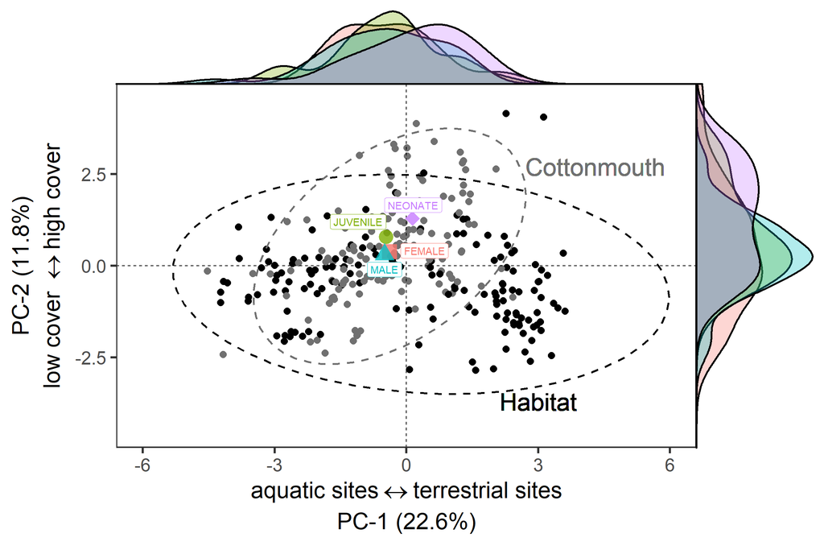

```r
xdens<-axis_canvas(p, axis = "x")+
geom_density(data =group, aes(Comp.1, fill = group$Group), alpha = 0.3, size =1)+
scale_fill_manual(values = c("#F8766D","#7CAE00","#00BFC4", "#C77CFF"))

ydens<-axis_canvas(p, axis = "y", coord_flip = TRUE)+
geom_density(data =group, aes(Comp.2, fill = group$Group), alpha = 0.3, size =1)+
  scale_fill_manual(values = c("#F8766D","#7CAE00","#00BFC4", "#C77CFF"))+
  coord_flip()

p1<-insert_xaxis_grob(p, xdens, grid::unit(0.2, "null"), position= "top")
p2<-insert_yaxis_grob(p1,ydens, grid::unit(0.2, "null"), position = "right")

ggdraw(p2)
```

**Figure 2:** Principal component analysis of the environmental variables measured for A. piscivorus (cottonmouth) and the available habitat comparison sites. Ellipses represent 95% confidence intervals for cottonmouth (grey) and available habitat (black). Mean principal component scores of the intra-specific cottonmouth conspecifics; adult males (blue), adult females (red), juveniles (green), and neonates (purple). Density counts of the cottonmouth conspecifics represented for each PC score, with PC-1 cottonmouth conspecific density above the plot, and PC-2 cottonmouth conspecific density toward the right of the plot.

**Table 2:** Results of the multivariate statistal tests PERMANOVA/PERMDISP based on the Euclidean distance comparing cottonmouth habitat selected and general habitat available to the cottonmouth within the study area.

```r
#PERMANOVA
Perm1<-adonis(s1[,c(2,3,4,5,6,7,8,9,10,11,12,13,14,15,16,22)]~ Type, data = s1, method='eu')
Perm1<-cbind(Perm1$aov.tab[1,4], Perm1$aov.tab[1,6])

#PERMDISP
dist<-dist(scale(s1[,c(2,3,4,5,6,7,8,9,10,11,12,13,14,15,16,22)]))
bd<-anova(betadisper(dist,s1$Type))
betadisper(dist,s1$Type)
```

```
##
##  Homogeneity of multivariate dispersions
##
## Call: betadisper(d = dist, group = s1$Type)
##
## No. of Positive Eigenvalues: 16
## No. of Negative Eigenvalues: 0
##
## Average distance to median:
## GENERAL   SNAKE
##   4.021   3.266
##
## Eigenvalues for PCoA axes:
## (Showing 8 of 16 eigenvalues)
##  PCoA1  PCoA2  PCoA3  PCoA4  PCoA5  PCoA6  PCoA7  PCoA8
## 1139.2  596.2  467.4  416.1  351.1  315.5  281.5  278.8
```

```r
bd1<-cbind(bd$`F value`, bd$`Pr(>F)`)
bd1<-data.frame(bd1)
bd1<-bd1[-2,]
PermDisp<- cbind(Perm1, bd1)
names(PermDisp)<-c("Pseudo-F", "P", "F", "P ")
row.names(PermDisp)<-c("Proportions (Euclidean)")

gt(PermDisp, rownames_to_stub = TRUE)%>%
  fmt_number(columns = c(1,3),
             decimals = 2,
             suffixing = T)%>%
    fmt_scientific(columns = c(2,4),
             decimals = 2)%>%
  tab_spanner(
    label = "PERMANOVA", columns = 1:2)%>%
  tab_spanner(
    label = "PERMDISP", columns = 3:4)%>%
  tab_source_note(
    source_note = "N(permutations) = 999")%>%
  tab_source_note(
    source_note = "df = 1")
```

|  | PERMANOVA Pseudo-F | PERMANOVA P | PERMDISP F | PERMDISP P |
| --- | --- | --- | --- | --- |
| Proportions (Euclidean) | 20.40 | 1.00 × 10<sup>−3</sup> | 25.44 | 7.75 × 10<sup>−7</sup> |

N(permutations) = 999  
df = 1

## 5.2 Habitat Selection: Intra-specific Differences

**Table 3:**Mean component scores of PCA on intra-specific habitat selection within cottonmouths with ANOVAs used to compare conspecific groups.

```r
pcomp<-pcomp[,2:4]
names(pcomp)<- c( "PC-1","PC-2", "PC-3")
row.names(pcomp)<-c("Female", "Juvenile", "Male", "YOY")
pcomp[,1:3]<-round(pcomp[,1:3], digits = 3)

C1<-aov(Comp.1~Group, group)
C2<-aov(Comp.2~Group, group)
C3<-aov(Comp.3~Group, group)

F.value<-c(anova(C1)$"F value"[1], anova(C2)$"F value"[1], anova(C3)$"F value"[1])
p.value<-c(anova(C1)$"Pr(>F)"[1],anova(C2)$"Pr(>F)"[1],anova(C3)$"Pr(>F)"[1])

stats<-data.frame(t(cbind(F.value, p.value)))
names(stats)<-c( "PC-1","PC-2", "PC-3")
pcomp<-rbind(pcomp,stats)

row.names(pcomp)<-c("Female", "Juvenile", "Male", "YOY", "F", "P-value")
pcomp<-round(pcomp, digits = 3)

gt(pcomp, rownames_to_stub = TRUE)%>%
  tab_stubhead(label = "Cottonmouth conspecific")%>%
  tab_row_group( group = "",
    rows = 1:4
  )%>%
  tab_row_group(
    group = "ANOVA",rows = c(5,6))
```

| Cottonmouth conspecific | PC-1 | PC-2 | PC-3 |
| --- | --- | --- | --- |
| Female | -0.384 | 0.380 | 0.047 |
| Juvenile | -0.457 | 0.784 | -0.208 |
| Male | -0.499 | 0.306 | -0.383 |
| YOY | 0.137 | 1.291 | -0.153 |
| ANOVA |  |  |  |
| F | 1.443 | 3.573 | 1.083 |
| P-value | 0.233 | 0.016 | 0.358 |

```r
#PC-1
TukeyHSD(C1)
```

```
##   Tukey multiple comparisons of means
##     95% family-wise confidence level
##
## Fit: aov(formula = Comp.1 ~ Group, data = group)
##
## $Group
##                         diff        lwr       upr     p adj
## JUVENILE-FEMALE  -0.07377182 -0.8842839 0.7367402 0.9953215
## MALE-FEMALE      -0.11513104 -0.7881744 0.5579123 0.9705643
## NEONATE-FEMALE    0.52022925 -0.3522491 1.3927076 0.4107216
## MALE-JUVENILE    -0.04135922 -0.7902528 0.7075343 0.9989407
## NEONATE-JUVENILE  0.59400107 -0.3382396 1.5262417 0.3508154
## NEONATE-MALE      0.63536029 -0.1801949 1.4509155 0.1836611
```

```r
#PC-2
TukeyHSD(C2)
```

```
##   Tukey multiple comparisons of means
##     95% family-wise confidence level
##
## Fit: aov(formula = Comp.2 ~ Group, data = group)
##
## $Group
##                         diff          lwr       upr     p adj
## JUVENILE-FEMALE   0.40419164 -0.437165510 1.2455488 0.5970571
## MALE-FEMALE      -0.07401275 -0.772669689 0.6246442 0.9926791
## NEONATE-FEMALE    0.91121876  0.005537089 1.8169004 0.0480018
## MALE-JUVENILE    -0.47820439 -1.255598063 0.2991893 0.3825382
## NEONATE-JUVENILE  0.50702713 -0.460691171 1.4747454 0.5253587
## NEONATE-MALE      0.98523152  0.138639308 1.8318237 0.0154326
```

```r
#PC-3
TukeyHSD(C3)
```

```
##   Tukey multiple comparisons of means
##     95% family-wise confidence level
##
## Fit: aov(formula = Comp.3 ~ Group, data = group)
##
## $Group
##                         diff        lwr       upr     p adj
## JUVENILE-FEMALE  -0.25527347 -1.0071504 0.4966035 0.8139792
## MALE-FEMALE      -0.42972754 -1.0540808 0.1946257 0.2828525
## NEONATE-FEMALE   -0.20000338 -1.0093638 0.6093570 0.9180857
## MALE-JUVENILE    -0.17445408 -0.8691702 0.5202620 0.9144662
## NEONATE-JUVENILE  0.05527008 -0.8095292 0.9200694 0.9983627
## NEONATE-MALE      0.22972416 -0.5268311 0.9862794 0.8592661
```

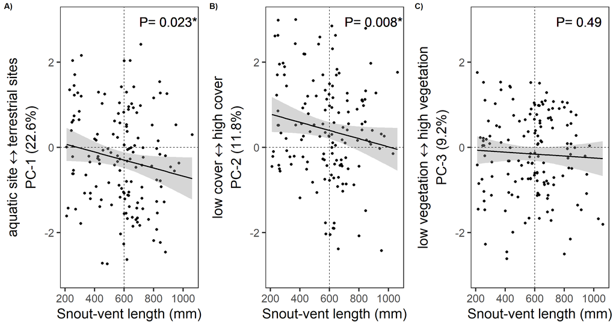

```r
#Linear Regression
mod<-lm(SVL~Comp.1,group)
mod2<-lm(SVL~Comp.2,group)
mod3<-lm(SVL~Comp.3,group)

LR1<-ggplot(group, aes(x= SVL, y= Comp.1))+
  geom_point(size = 2)+
  xlim(209, 1061)+
  geom_smooth(method = "lm", color= "black")+
  geom_hline(yintercept = 0, lty = 2) +
  geom_vline(xintercept = 600, lty = 2)+
  theme_bw(base_size = 24)+
  #geom_text(aes(900, 6, label = paste("R-squared = 0.034")), color="black")+
  geom_text(aes(900, 2.95, label = paste("P= 0.023*")), color = "black", size=8)+
  xlab("Snout-vent length (mm)")+
  ylab(expression(atop("aquatic site" %<->% "terrestrial sites", paste("PC-1 (22.6%)" ))))+
  ylim(-3,3)+
  guides(shape = "none")+
  theme(panel.grid = element_blank(), panel.border = element_rect(fill= "transparent"))

LR2<-ggplot(group, aes(x= SVL, y= Comp.2))+
  geom_point(size = 2)+
  xlim(209, 1061)+
  geom_smooth(method = "lm", color= "black")+
  geom_hline(yintercept = 0, lty = 2) +
  geom_vline(xintercept = 600, lty = 2)+
  theme_bw(base_size = 24)+
  #geom_text(aes(900, 6, label = paste("R-squared = 0.045")), color="black")+
  geom_text(aes(900, 2.95, label = paste("P= 0.008*")), color = "black", size = 8)+
  xlab("Snout-vent length (mm)")+
  ylab(expression(atop("low cover" %<->% "high cover", paste("PC-2 (11.8%)" ))))+
  ylim(-3,3)+
  guides(shape = "none")+
  theme(panel.grid = element_blank(), panel.border = element_rect(fill= "transparent"))

LR3<-ggplot(group, aes(x= SVL, y= Comp.3))+
  geom_point(size = 2)+
  xlim(209, 1061)+
  geom_smooth(method = "lm", color= "black")+
  geom_hline(yintercept = 0, lty = 2) +
  geom_vline(xintercept = 600, lty = 2)+
  theme_bw(base_size = 24)+
  #geom_text(aes(900, 6, label = paste("R-squared = 0.045")), color="black")+
  geom_text(aes(900, 2.95, label = paste("P= 0.49")), color = "black", size = 8)+
  xlab("Snout-vent length (mm)")+
  ylab(expression(atop("low vegetation" %<->% "high vegetation", paste("PC-3 (9.2%)" ))))+
  ylim(-3,3)+
  guides(shape = "none")+
  theme(panel.grid = element_blank(), panel.border = element_rect(fill= "transparent"))

plot_grid(LR1, LR2, LR3, labels=c("A)", "B)", "C)"), ncol = 3, nrow = 1)
```

```r
summary(mod)
```

```
##
## Call:
## lm(formula = SVL ~ Comp.1, data = group)
##
## Residuals:
##    Min     1Q Median     3Q    Max
## -454.4 -156.4   25.8  127.4  505.3
##
## Coefficients:
##             Estimate Std. Error t value Pr(>|t|)
## (Intercept)   564.69      17.12  32.990   <2e-16 ***
## Comp.1        -29.97      13.04  -2.298    0.023 *
## ---
## Signif. codes:  0 '***' 0.001 '**' 0.01 '*' 0.05 '.' 0.1 ' ' 1
##
## Residual standard error: 200.6 on 147 degrees of freedom
## Multiple R-squared:  0.03468,    Adjusted R-squared:  0.02812
## F-statistic: 5.282 on 1 and 147 DF,  p-value: 0.02296
```

```r
summary(mod2)
```

```
##
## Call:
## lm(formula = SVL ~ Comp.2, data = group)
##
## Residuals:
##     Min      1Q  Median      3Q     Max
## -398.35 -144.82   16.46  115.71  524.34
##
## Coefficients:
##             Estimate Std. Error t value Pr(>|t|)
## (Intercept)   593.91      17.72  33.516  < 2e-16 ***
## Comp.2        -32.50      12.23  -2.657  0.00875 **
## ---
## Signif. codes:  0 '***' 0.001 '**' 0.01 '*' 0.05 '.' 0.1 ' ' 1
##
## Residual standard error: 199.4 on 147 degrees of freedom
## Multiple R-squared:  0.04583,    Adjusted R-squared:  0.03934
## F-statistic:  7.06 on 1 and 147 DF,  p-value: 0.008752
```

```r
summary(mod3)
```

```
##
## Call:
## lm(formula = SVL ~ Comp.3, data = group)
##
## Residuals:
##     Min      1Q  Median      3Q     Max
## -373.01 -151.93   30.15  124.13  469.45
##
## Coefficients:
##             Estimate Std. Error t value Pr(>|t|)
## (Intercept)  573.667     16.952  33.840   <2e-16 ***
## Comp.3        -9.922     14.335  -0.692     0.49
## ---
## Signif. codes:  0 '***' 0.001 '**' 0.01 '*' 0.05 '.' 0.1 ' ' 1
##
## Residual standard error: 203.8 on 147 degrees of freedom
## Multiple R-squared:  0.003248,   Adjusted R-squared:  -0.003532
## F-statistic: 0.4791 on 1 and 147 DF,  p-value: 0.4899
```

## 5.3 Habitat Selection: Modeling Habitat Preference

```r
#Went with the Full Model
rf<-s1[,c(1,2,3,4,5,6,7,8,9,10,11,12,13,14,15,16,22)]
```

```r
#Setting up Cross Validation Training and Validation sets
set.seed(123)
ind<-sample(2,nrow(rf),replace = T, prob = c(0.9,0.1))
train<-rf[ind==1,]
test<-rf[ind==2,]
```

```r
OOB1<-c(a1$err.rate[6000,1],a2$err.rate[6000,1],a3$err.rate[6000,1],a4$err.rate[6000,1],a5$err.rate[6000,1],a6$err.rate[6000,1],
       a7$err.rate[6000,1],a8$err.rate[6000,1],a9$err.rate[6000,1],a10$err.rate[6000,1],b1$err.rate[6000,1],b2$err.rate[6000,1],
       b3$err.rate[6000,1],b4$err.rate[6000,1],b5$err.rate[6000,1],b6$err.rate[6000,1],b7$err.rate[6000,1],b8$err.rate[6000,1],
       b9$err.rate[6000,1],b10$err.rate[6000,1],c1$err.rate[6000,1],c2$err.rate[6000,1],c3$err.rate[6000,1],c4$err.rate[6000,1],
       c5$err.rate[6000,1],c6$err.rate[6000,1],c7$err.rate[6000,1],c8$err.rate[6000,1],c9$err.rate[6000,1],c10$err.rate[6000,1])
OOB<-c(1-min(OOB1),1-mean(OOB1), 1-max(OOB1))
OOB1
```

```
##       OOB       OOB       OOB       OOB       OOB       OOB       OOB
## 0.1562500 0.1562500 0.1562500 0.1527778 0.1562500 0.1527778 0.1493056
##       OOB       OOB       OOB       OOB       OOB       OOB       OOB
## 0.1493056 0.1562500 0.1597222 0.1493056 0.1493056 0.1597222 0.1631944
##       OOB       OOB       OOB       OOB       OOB       OOB       OOB
## 0.1631944 0.1562500 0.1562500 0.1597222 0.1527778 0.1527778 0.1597222
##       OOB       OOB       OOB       OOB       OOB       OOB       OOB
## 0.1493056 0.1562500 0.1562500 0.1562500 0.1562500 0.1562500 0.1562500
##       OOB       OOB
## 0.1597222 0.1597222
```

```r
files<-list(a1,a2,a3,a4,a5,a6,a7,a8,a9,a10,b1,b2,b3,b4,b5,b6,b7,b8,b9,b10,c1,c2,c3,c4,c5,c6,c7,c8,c9,c10)

cv<-(function(x){
p<-predict(x, test)
cm<-caret::confusionMatrix(p, positive = "SNAKE",test$Type)

CVTABLE<-t(data.frame(cm$overall))
CV2TABLE<-t(data.frame(cm$byClass))

cv_table<-cbind(CVTABLE,CV2TABLE)
cv_table<-cv_table[,c(1,2,8,9)]
cv_table
})

cv_table<-t(data.frame(lapply(files, cv)))

cv_max<-c(max(cv_table[,1]), max(cv_table[,2]), max(cv_table[,3]), max(cv_table[,4]))
cv_mean<-c(mean(cv_table[,1]), mean(cv_table[,2]), mean(cv_table[,3]), mean(cv_table[,4]))
cv_min<-c(min(cv_table[,1]), min(cv_table[,2]), min(cv_table[,3]), min(cv_table[,4]))

cv_table<-data.frame(rbind(cv_max,cv_mean, cv_min))

RandomForest_Model<-c("Maximum", "Mean", "Minimum")
```

```r
AUC<- function(z){
pred<-predict(z, test, type = "prob")
pred<-pred[,2]
pred<-prediction(pred, test$Type)

#AUC (Area Under The Curve)
auc<-performance(pred, "auc")
auc<-unlist(slot(auc, "y.values"))

}

AUC<-t(data.frame(lapply(files, AUC)))

AUC<-c(max(AUC), mean(AUC), min(AUC))
```

**Table 4:** Performance metrics for the 30-iteration random forest model on cottonmouth habitat selection compared to general habitat available within the study area.

```r
models<-cbind(cv_table, OOB, AUC)
models<-round(models, digits = 3)
models<-cbind(RandomForest_Model,models)
gt(models)%>%
  cols_label(
    RandomForest_Model = "Random Forest Models",
    X1 = "Accuracy",
    X2 = "Kappa",
    X3 = "Sensitivity",
    X4 = "Specificity")%>%
  tab_source_note(
    source_note = "N(trees) = 6000")%>%
  tab_source_note(
    source_note = "OOB = Out of Bag Accuracy")%>%
    tab_source_note(
    source_note = "AUC = Area Under the Curve")
```

| Random Forest Models | Accuracy | Kappa | Sensitivity | Specificity | OOB | AUC |
| --- | --- | --- | --- | --- | --- | --- |
| Maximum | 0.893 | 0.786 | 0.867 | 0.923 | 0.851 | 0.944 |
| Mean | 0.890 | 0.781 | 0.862 | 0.923 | 0.844 | 0.934 |
| Minimum | 0.857 | 0.716 | 0.800 | 0.923 | 0.837 | 0.928 |

N(trees) = 6000  
OOB = Out of Bag Accuracy  
AUC = Area Under the Curve

```r
a7 # Maximum Accuracy
```

```
##
## Call:
##  randomForest(formula = Type ~ ., data = train, ntree = 6000,      importance = T)
##                Type of random forest: classification
##                      Number of trees: 6000
## No. of variables tried at each split: 4
##
##         OOB estimate of  error rate: 14.93%
## Confusion matrix:
##         GENERAL SNAKE class.error
## GENERAL     132    22   0.1428571
## SNAKE        21   113   0.1567164
```

```r
a1 #Mean Accuracy
```

```
##
## Call:
##  randomForest(formula = Type ~ ., data = train, ntree = 6000,      importance = T)
##                Type of random forest: classification
##                      Number of trees: 6000
## No. of variables tried at each split: 4
##
##         OOB estimate of  error rate: 15.62%
## Confusion matrix:
##         GENERAL SNAKE class.error
## GENERAL     130    24   0.1558442
## SNAKE        21   113   0.1567164
```

```r
MDA<-randomForest::importance(a7, class = "SNAKE")
MDA<-data.frame(MDA[,c(1,2)])
gen<-sum(MDA[,1])
sna<-sum(MDA[,2])
#Calculating relative importance of MDA
MDA[,1]<-(MDA[,1]/gen)*100
MDA[,2]<-(MDA[,2]/gen)*100

#Plotting
Habitat_Variables <- c("Canopy Closure", "Rock Cover", "Leaf Cover", "Vegetative Cover","Fallen Log Cover","Woody Stem Height", "Cover Height", "Distance To Cover","Log Diameter","Distance To Water", "Water Depth", "Percent Water", "Percent Woody Debris", "Percent Floating Vegetation", "Percent Bare Soil", "Mean Temperature")

D<-cbind(Habitat_Variables,MDA)
row.names(D)<-NULL

Q=ggplot(D, aes(x = reorder(Habitat_Variables, D$SNAKE), y = D$SNAKE))+
  geom_col(aes(fill=D$SNAKE), color = "black", width = 0.9)+
  geom_text(label=round(D$SNAKE,1), nudge_y = 0.5)+
    ylab("Relative Importance")+
  xlab("Environmental Variables")+
  coord_flip()+
  theme_classic(base_size = 12)+ theme(legend.position = "none")

Q<-Q+scale_fill_gradient2(low="white", high="black")
```

```r
#RF a7
plotx<-partial(a7, pred.var = "Dist..To.Water", pdp = T, center = T, plot = T, plot.engine = "ggplot2", type = "classification", which.class = "SNAKE", train = train, rug = T)

ploty<-partial(a7, pred.var = "X.Bare.soil", pdp = T, center = T, plot = T, plot.engine = "ggplot2", type = "classification", which.class = "SNAKE", train = train, rug = T)

plotz<-partial(a7, pred.var = "Rock.Cover", pdp = T, center = T, plot = T, plot.engine = "ggplot2", type = "classification", which.class = "SNAKE", train = train, rug = T)

plotz1<-partial(a7, pred.var = "Depth", pdp = T, center = T, plot = T, plot.engine = "ggplot2", type = "classification", which.class = "SNAKE", train = train, rug = T)

plotz2<-partial(a7, pred.var = "X.Water", pdp = T, center = T, plot = T, plot.engine = "ggplot2", type = "classification", which.class = "SNAKE", train = train, rug = T)

plotz3<-partial(a7, pred.var = "Dist..To.Cover", pdp = T, center = T, plot = T, plot.engine = "ggplot2", type = "classification", which.class = "SNAKE", train = train, rug = T)

#GGPLOT

plot1<-ploty+ geom_line(size = 1.5)+
  xlab("Bare soil cover (%)")+
  ylab("Relative probability")+
  xlim(0,105)+
  theme_light(base_size = 12)

plot2<-plotx+geom_line(size = 1.5)+
  xlab("Distance to Water (cm)")+
  ylab("")+
  ylim(-1.05,0.35)+
  theme_light(base_size = 12)

plot3<-plotz+ geom_line(size = 1.5)+
  xlab("Rock cover (%)")+
  ylab("")+
  theme_light(base_size = 12)

plot4<-plotz1+ geom_line(size = 1.5)+
  xlab("Water Depth (cm)")+
  ylab("Relative probability")+
  xlim(0,105)+
  theme_light(base_size = 12)

plot5<-plotz2+ geom_line(size = 1.5)+
  xlab("Water Cover (%)")+
  ylab("")+
  xlim(0,105)+
  ylim(-0.80, 0.25)+
  theme_light(base_size = 12)

plot6<-plotz3+ geom_line(size = 1.5)+
  xlab("Distance to Cover (cm)")+
  ylab("")+
  ylim(-0.65,-0.2)+
  theme_light(base_size = 12)
```

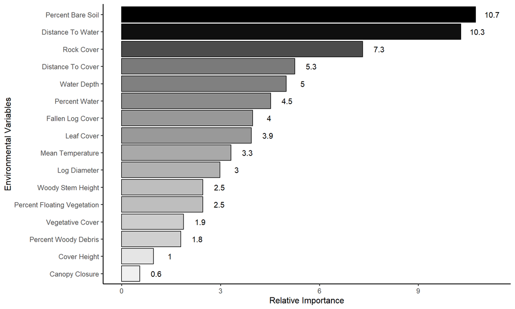

```r
Q
```

**Figure 3:** The Relative Importance (based on the Mean Decrease Accuracy) on the environmental variables from the minimum error rate random forest model on Cottonmouth (Agkistrodon piscivorus) habitat selection in Middle TN, USA. Cover variables were measured in percentage of occurance within a 1-m^2 quadrat, and all other metrics were measured in cm.

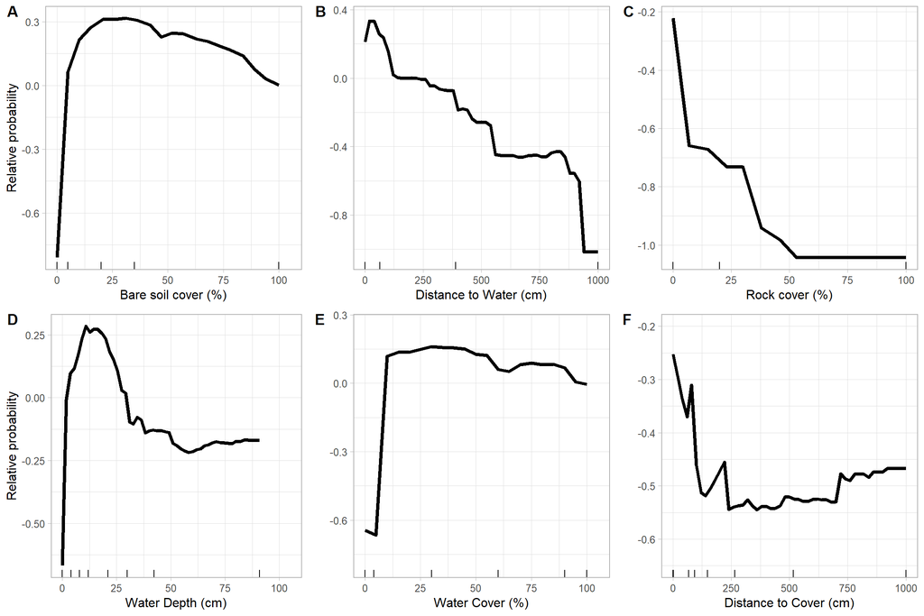

```r
plot_grid(plot1, plot2,plot3,plot4,plot5,plot6, labels=c("A ", "B ", "C ","D ", "E ", "F "), ncol = 3, nrow = 2)
```

# 6 **Discussion**

Cottonmouths are pretty generalist, manly sticking to the swamp, but can be found in the terrestrial zones of the study area. Also, there is a presence of an ontogenetic shift in both terrestrial to wetland habitat, as well as being near more cover objects.

# 7 **References**

Anderson, M. J. 2017. Permutational Multivariate Analysis of Variance (PERMANOVA). Wiley StatsRef: Statistics Reference Online:1–15.

Anderson, M. J., K. E. Ellingsen, and B. H. McArdle. 2006. Multivariate dispersion as a measure of beta diversity. Ecology Letters 9:683–693.

Archer, K. J., and R. V. Kimes. 2008. Empirical characterization of random forest variable importance measures. Computational Statistics and Data Analysis 52:2249–2260.

Assis, J., B. Claro, A. Ramos, J. Boavida, and E. A. Serrão. 2013. Performing fish counts with a wide-angle camera, a promising approach reducing divers’ limitations. Journal of Experimental Marine Biology and Ecology 445:93–98.

Blanchard, F, N., and B. Finister, E. 1933. A method of marking living snakes for future recognition, with a discussion of some problems and results. Ecology 14:334–347.

Breiman, L. 2001. Random Forest. Machine Learning 45:5–32.

Breiman, L., A. Cutler, A. Liaw, and M. Wiener. 2018. Breiman and Cutler’s Random Forests for Classification and Regression “randomForest.” CRAN.

Brückner, A., and M. Heethoff. 2017. A chemo-ecologists’ practical guide to compositional data analysis. Chemoecology 27:33–46.

Burkett, Ray, D. 1966. Natural history of cottonmouth moccasin, *Agkistrodon piscivorus (Reptilia). University of Kansas Publications 17:435–491.*

Cutler, D. R., T. C. Edwards, K. H. Beard, A. Cutler, T. Kyle, J. Gibson, J. J. Lawler, H. Beard, and T. Hess. 2007. Random Forests for Classification in Ecology Published by : Ecological Society of America. Ecology 88:2783–2792.

Delgado-Baquerizo, M., A. Gallardo, F. Covelo, A. Prado-Comesaña, V. Ochoa, and F. T. Maestre. 2015. Differences in thallus chemistry are related to species-specific effects of biocrust-forming lichens on soil nutrients and microbial communities. Functional Ecology 29:1087–1098.

Dormann, C. F., J. Elith, S. Bacher, C. Buchmann, G. Carl, G. Carré, J. R. G. Marquéz, B. Gruber, B. Lafourcade, P. J. Leitão, T. Münkemüller, C. Mcclean, P. E. Osborne, B. Reineking, B. Schröder, A. K. Skidmore, D. Zurell, and S. Lautenbach. 2013. Collinearity: A review of methods to deal with it and a simulation study evaluating their performance. Ecography 36:027–046.

Eskew, E. A., J. D. Willson, and C. T. Winne. 2009. Ambush site selection and ontogenetic shifts in foraging strategy in a semi-aquatic pit viper, the Eastern cottonmouth. Journal of Zoology 277:179–186.

Frakes, R. A., R. C. Belden, B. E. Wood, and F. E. James. 2015. Landscape analysis of adult Florida panther habitat. PLoS ONE 10:1–18.

Guttman, L. 1954. Some necessary conditions for common-factor analysis. Psychometrika 19:149–161.

Hirzel, A. H., J. Hausser, D. Chessel, and N. Perrin. 2002. Ecological-niche factor analysis: How to compute habitat-suitability maps without absence data? Ecology 83:2027–2036.

Koons, D. N., R. D. Birkhead, S. M. Boback, M. I. Williams, and M. P. Greene. 2009. The effect of body size on cottonmouth (Agkistrodon piscivorus) survival, recapture probability, and behavior in an Alabama swamp. Herpetological Conservation and Biology 4:221–235.

Murphy, M. A., J. S. Evans, and A. Storfer. 2010. Quantifying Bufo boreas connectivity in Yellowstone National Park with landscape genetics. Ecology 91:252–261.

Oksanen, J., M. Guillaume - Blanchet, F. Friendly, R. Kindt, P. Legendre, D. McGlinn, P. R. Minchin, R. B. O’Hara, G. L. Simpson, P. Solymos, M. Henry, H. Stevens, E. Szoecs, and H. Wagner. 2019. Community Ecology Package “vegan.” CRAN.

Pape, R., and J. Löffler. 2015. Seasonality of habitat selection shown to buffer alpine reindeer pastoralism against climate variability. Ecosphere 6:1–18.

Peres-Neto, P. R., D. A. Jackson, and K. M. Somers. 2003. Giving meaningful interpretation to ordination axes: Assessing loading significance in principal component analysis. Ecology 84:2347–2363.

Peres-Neto, P. R., D. A. Jackson, and K. M. Somers. 2005. How many principal components? stopping rules for determining the number of non-trivial axes revisited. Computational Statistics and Data Analysis 49:974–997.

Severson, J. P., C. A. Hagen, J. D. Maestas, D. E. Naugle, J. T. Forbes, and K. P. Reese. 2017. Effects of conifer expansion on greater sage-grouse nesting habitat selection. Journal of Wildlife Management 81:86–95.

Smith, N. 2009. Studies on selected aspects of the life history of the Western Cottonmouth ( Akgistrodon piscivorus leucostoma) along the Cumberland River Bicentennial Trail, Ashland City, Tennessee. Unpublished M.S. Thesis, Austin Peay State University, Clarksville, Tennessee.

Jack Kauphusman

12/10/2019